# America Reconsidered

The Republic of Concordia

# The American Project at Age 249

Lincoln would say that we are again a house divided that cannot stand. He ended the division of his day by pulling down half the house, and his successors rebuilt that half along similar lines as the original. Johnson took a backhoe to that successor version, and Trump is busy building it back while undermining the foundations supporting the remainder.

It’s unlikely that the rest of the United States would let New England go its own way unless it was part of a general plan of reorganization. If that were to occur, many thorny problems, such as defense, currency, inter-regional commerce and the like, would need to be addressed. However, if 37 states agree on amending the Constitution on the fundamental question of allowing for dissolution—a big if—I am assuming those problems away.

How that will play out will take more years to unfold than I have to observe the changes. What I can do is the thought experiment of taking my toys and going home by looking at what an American breakaway republic might look like.

I’ve chosen New England, which I’ve dubbed *Concordia.*

# Concordia in Context

[interactive chart not shown]

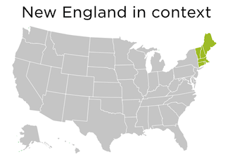

Index map

All of Concordia lies within 200 miles of Boston except for northeastern Maine, which is sparsely settled. It is bordered by Quebec, Canada on the north and by New Brunswick, Canada on the east. It borders New York on the west and south. Approximately 75% of the region is forested.

# Population

| State | Population |
| --- | --- |
| Massachusetts | 6,992,395 |
| Connecticut | 3,598,348 |
| New Hampshire | 1,387,834 |
| Maine | 1,377,400 |
| Rhode Island | 1,095,371 |
| Vermont | 645,254 |

New England is home to approximately 15.1 million in the six states of Connecticut, New Hampshire, Maine, Massachusetts, Rhode Island and Vermont. As a single state, it would be the fifth largest, behind New York and ahead of Pennsylvania. It has about 4.5% of the total population of the United States.

Its population is concentrated along the Northeast Corridor from Boston to New York. Massachusetts has a population size similar to Indiana and Tennessee. Connecticut falls between Utah and Oklahoma. Maine and New Hampshire are both comparable to Hawaii. Rhode Island has the approximate population of Delaware and Montana. Vermont has a larger population than Wyoming and a smaller population than the District of Columbia.

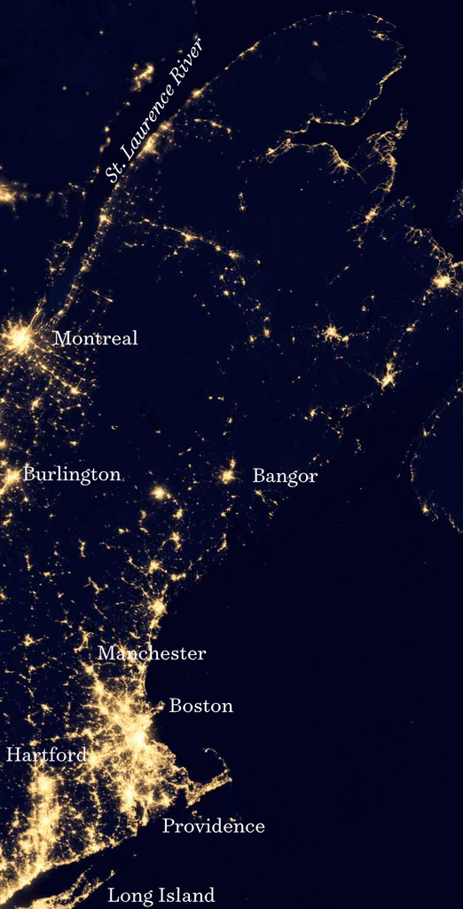

New England at night

Its closest global peer nation in terms of population is Guinea. It is roughly the same size as Denmark, Norway and Finland combined or Sweden and one of those other Scandinavian states.

## Age Structure

[figure not shown]

[figure not shown]

The age distribution differences are reflected in the dependency ratios for the New England states.

| State | Dependency Ratio |
| --- | --- |
| Massachusetts | 50.23 |
| Rhode Island | 51.07 |
| New Hampshire | 52.66 |
| Connecticut | 52.88 |
| Vermont | 55.07 |
| Maine | 58.14 |

A lower dependency ratio indicates a higher proportion of the population in the 16-65 age group. For the US as a whole, the ratio is 54.86.

## Change components

### Fertility

The estimated total fertility rate per thousand women for the United State is approximately 1.62, which is less than the 2.1 rate to maintain population levels in the absence of migration.

Sources: [Hamilton BE, Martin JA, Osterman MJK. Births: provisional data for 2023. Vital Statistics Rapid Release; no 35. April 2024](https://dx.doi.org/10.15620/%20cdc/151797); Gokhale, Jagadeesh, [U.S. Demographic Projections: With and Without Immigration, 2024](https://budgetmodel.wharton.upenn.edu/issues/2024/3/22/us-demographic-projections-with-and-without-immigration). [Fertility rates by state](https://www.cdc.gov/nchs/pressroom/sosmap/fertility_rate/fertility_rates.htm) [Total fertility rates by state](https://en.wikipedia.org/wiki/List_of_U.S._states_and_territories_by_fertility_rate#cite_note-4) [UMass Donahue Institute. Source U.S. Census Bureau Population Division NST_EST2024_ALLDATA. Release Date December 19, 2024](https://donahue.umass.edu/business-groups/economic-public-policy-research/massachusetts-population-estimates-program/population-estimates-by-massachusetts-geography/by-state)

In the New England States,

| State | Total Fertility Rate |
| --- | --- |
| Connecticut | 1.55 |
| Maine | 1.47 |
| Massachusetts | 1.44 |
| New Hampshire | 1.41 |
| Rhode Island | 1.4 |
| Vermont | 1.35 |

Together with the District of Columbia and Oregon, the New England states have the lowest total fertility rates in the United States. Massachusetts and Connecticut have death rates below the national average, while the other New England states have rates that are higher.

Sources: Centers for Disease Control and Prevention, National Center for Health Statistics. National Vital Statistics System, Mortality 2018-2023 on CDC WONDER Online Database, released in 2024. Data are from the [Multiple Cause of Death Files, 2018-2023, as compiled from data provided by the 57 vital statistics jurisdictions through the Vital Statistics Cooperative Program.](http://wonder.cdc.gov/ucd-icd10-expanded.html)

### Growth

The other component of population is the net flow of population in and out from other states and from abroad.

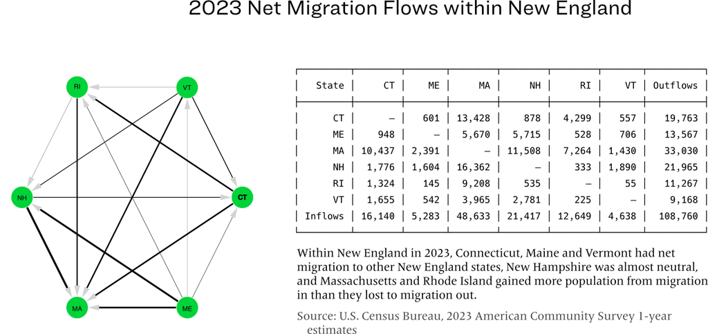

| State | Births | Deaths | Natural Increase | International Migration | Domestic Migration | Total Net Migration |
| --- | --- | --- | --- | --- | --- | --- |
| Connecticut | 34,609 | 32,778 | 1831 | 36,214 | -6,060 | 30,154 |
| Maine | 11,609 | 16,766 | -5,157 | 5,196 | 5,329 | 10,525 |
| Massachusetts | 67,851 | 61,133 | 6,718 | 90,217 | -27,480 | 62,737 |
| New Hampshire | 11,777 | 14,140 | -2,363 | 4,290 | 4,889 | 9,179 |
| Rhode Island | 9,924 | 10,286 | -362 | 9,525 | -305 | 9,220 |
| Vermont | 5,039 | 6,762 | -1,723 | 2,024 | -511 | 1,513 |

Massachusetts and Connecticut have natural increase, while the other New England stats have an excess of deaths over births. Maine and New Hampshire had net increases domestic migration and all states had growth due to international migration.

# Economy

Sources. Office of the U.S. Trade Representative. [Massachusetts](https://ustr.gov/map/state-benefits/ma)[Connecticut](https://ustr.gov/map/state-benefits/ct), [New Hampshire](https://ustr.gov/map/state-benefits/nh), [Maine](https://ustr.gov/map/state-benefits/me), [Rhode Island](https://ustr.gov/map/state-benefits/ri) and [Vermont](https://ustr.gov/map/state-benefits/vt).

New England has a gross domestic product that falls between the Netherlands and Indonesia. It ranks fourth, behind New York, ahead of Florida. It accounts for about 6.4% of the national gross domestic product. The six New England states collectively exported $66.2 billion in goods to the world in 2023, with Massachusetts leading at $35.2 billion, followed by Connecticut at $\15.8 billion, New Hampshire at $7.6 billion in exports and Rhode Island at $3.0 billion34. The region’s economic strength in trade goods lies in sectors such as chemical manufacturing, aerospace, computer and electronic products, and precision machinery. However, most states face trade deﬁcits due to reliance on imports for raw materials and consumer goods. Services exports, particularly in education, digital trade, and management consulting, play a signiﬁcant role in offsetting goods deficits, with Massachusetts and Connecticut each exporting $15 billion in 2023

## Manufacturing

New England’s industries include high-value specialty chemicals specialty polymers, pharmaceutical intermediates, and advanced materials used in electronics, healthcare, and other high-tech sectors. Its aerospace industry includes propulsion, avionics, and systems engineering for unmanned systems, advanced sensor technologies, satellite components, and precision-engineered aerospace parts. General Dynamics Electric Boat division designs, manufactures, maintains and retrofits submarines for the U.S. Navy.

## Foods

New England agriculture is a diversified mix of livestock, dairy, fruits, vegetables, and specialty crops. The principal monoculture farming is the potato fields of Arostook County in Maine. Fishing and aquaculture activity includes lobster, cod, haddock and clams.

## Resource Extraction

Maine has a timber and paper industry and Vermont, New Hampshire and Massachusetts quarry dimension stone.

## Services

Financial services, education, healthcare, intellectual property licensing, information technology, and professional consulting, together with tourism, are the leading components of exports in services.

## Balance of trade

Massachusetts and Connecticut, despite high export values, have international trade deficits of $16.3 billion and $5.6 billion respectively in goods. New Hampshire maintains a smaller deficit of $1.9 billion, while Rhode Island experiences a substantial $12.4 billion shortfall. Maine’s international trade deficit reaches $15.0 billion, primarily due to petroleum imports. Vermont, with limited data available, shows an estimated $500 million deficit.

[Maine State of Domestic Trade Annual Report 2024](https://www.maine.gov/decd/sites/maine.gov.decd/files/inline-files/Final%20Report%20-%202024%20Annual%20Macro%20Update%20-%20Maine%20DECD.pdf)

Domestically, Maine has a $79.3 billion trade surplus with other U.S. states, driven by forest products and seafood exports. Massachusetts and Connecticut leverage their tech and aerospace sectors for positive domestic balances of $12.9 billion and $3.8 billion respectively. New Hampshire and Vermont also maintain modest domestic surpluses, while Rhode Island is the only state with a negative balance in both international and domestic trade.

# Assessment

Assuming that US markets remain open to New England, it would be a viable standalone nation if it continues to absorb foreign immigration and can meet challenges in housing costs.